# Modulo 7a: Confirmatory Factor Analysis - CFA

Autore/Autrice

Ottavia M. Epifania, Margherita Calderan

# 1 La soluzione migliore trovata con EFA:

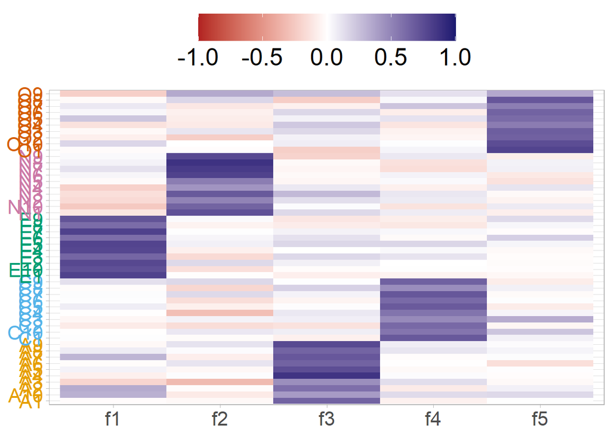

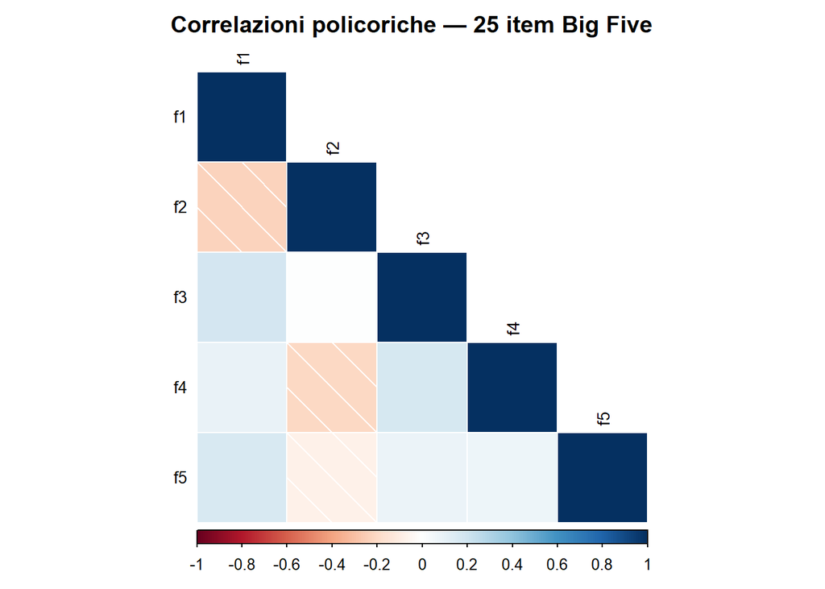

con $n = 498$

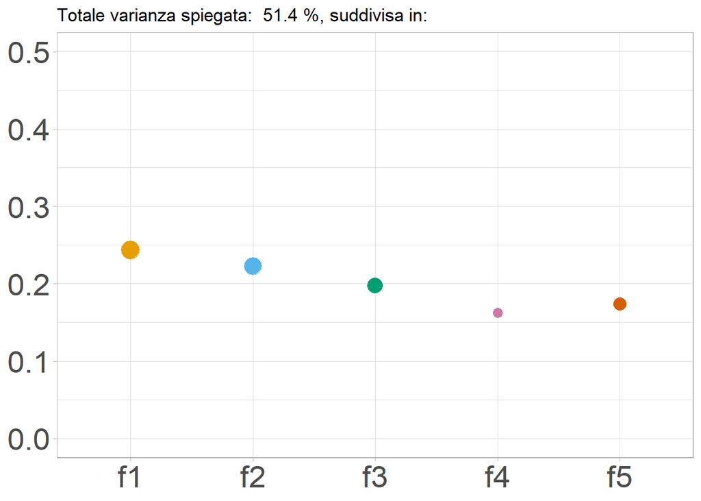

# 2 CFA

Permette di testare delle ipotesi specificando a priori un modello dove vengono esplicitate:

- Le relazioni indicatore – fattore latente
- I rapporti tra i fattori latenti

**Ipotesi sotto esame**

Ogni indicatore è la realizzazione di un singolo e specifico fattore latente

Ogni indicatore satura su una specifica dimensione latente **definita a priori sulla base di un modello teorico**

**Il modello teorico**

$$\mathbf{Y}_p = \mathbf{\mu} + \mathbf{\Lambda} \mathbf{\theta}_p + \varepsilon_p$$
con

$\mathbf{Y}_p \in \mathbb{R}^{I \times 1}$: Vettore delle risposte a tutti gli $I$ indicatori della persona $p$

$\boldsymbol{\mu} \in \mathbb{R}^{I \times 1}$: Vettore dei valori medi attesi di tutti gli $I$ indicatori

$\mathbf{\Lambda} \in \mathbb{R}^{I \times F}$: Matrice $I \times F$ delle saturazioni degli $I$ item sulle $F$ dimensioni latenti

$\boldsymbol{\theta}_p \in \mathbb{R}^{F \times 1}$: Vettore dei factors scores – ovvero dei livelli latenti attesi – sulle $F$ dimensioni latenti per la persona $p$

$\boldsymbol{\varepsilon}_p \in \mathbb{R}^{I \times 1}$: vettore degli errori/residui associati agli indicatori della persona p

# 3 Analisi delle strutture di covarianza Joreskog (1969)

Matrice di covarianza **osservata**

$$S$$

Matrice di covarianza **attesa** sulla base del modello teorico

$$\Sigma(\zeta)$$

con $\zeta$ che contiene tutti i parametri del modello (saturazioni, varianze, covarianze, errori specifici)

**OBIETTIVO**

Stimare i parametri a partire dalla matrice di covarianza osservata in modo che:

$$S \approx \Sigma(\zeta)$$

# 4 Statistiche di fit per modelli CFA

## 4.1 $\chi^2$

$H_0$: $S = \Sigma(\zeta)$

$df = \dfrac{I(I+1)}{2} - t$, dove $I$ è il numero di indicatori e $t$ il numero di parameteri liberi che si va a stimare nel modello contenuti in $\zeta$

Se $I = 4$, la matrice di covariana è:

$$S =
\begin{pmatrix}
\mathbf{s_{11}} & \color{pink}{s_{12}} & \color{pink}{s_{13}} & \color{pink}{s_{14}} \\
\color{blue}{s_{21}} & \mathbf{s_{22}} & \color{pink}{s_{23}} & \color{pink}{s_{24}} \\
\color{blue}{s_{31}} & \color{blue}{s_{32}} & \mathbf{s_{33}} & \color{pink}{s_{34}} \\
\color{blue}{s_{41}} & \color{blue}{s_{42}} & \color{blue}{s_{43}} & \mathbf{s_{44}}
\end{pmatrix}$$

Ci sono $\dfrac{I(I+1)}{2} = \dfrac{4(4+1)}{2} = 10$ elementi unici:

- 4 varianze nella diagonale principale (in grassetto)
- 6 covarianze o nel triangolo inferiore (in blu) O nel triangolo superiore (in rosa)

### 4.1.1 La logica dei $df$

**$df > 0$ (Overidentified)**

Il modello è testabile perché c’è *più informazione nei dati* di quanto richiesto dal modello

La matrice di covarianza $S$ non può essere riprodotta perfettamente da $\Sigma(\zeta)$: Il modello è falsificabile

**$df = 0$ (Just identified)**

Situazione al limite dove il numero di parametri è uguale ai dati empirici.

La matrice di covarianza $S$ può perfettamente essere riprotta da $\Sigma(\zeta)$

Il modello non è falsificabile

**$df < 0$ (Underidentified)**

Ci sono più parametri che informazione disponibile

Diversi set di parametri possono essere usati per $\Sigma(\zeta)$ (sistema indeterminato, non esiste una soluzione unica)

## 4.2 Root mean square error of approximation (RMSEA)

Indice di fit assoluto basato sul $\chi^2$:

$RMSEA = \dfrac{\chi^2 -df}{df(n-1)}$

$E(\chi^2) = df$ $\rightarrow$ più è piccolo il valore di RMSEA, minore è l’errore, migliore è il modello

$RMSEA < .10$ fit accettabile

$RMSEA < .05$ fit ottima

## 4.3 Comparative Fit Index (CFI)

Confronta la performance del modello target ($T$) e di un modello baseline ($B$) in cui tutte le covarianze sono fissate a 0 (non c’è correlazione tra le variabili manifeste) e le varianze sono stimate liberamente a partire dai dati:

$$CFI = \dfrac{(\chi_B^2 - df_B) - (\chi_T^2 - df_T)}{(\chi_B^2 - df_B)}$$

Se il modello $T$ è correttamente specificato: $(\chi_T^2 - df_T) \approx 0 \rightarrow CFI \approx 1$

$CFI \geq .90$ Valori accettabili

$CFI \geq .95$ Valori ottimali

## 4.4 Tucker-Lewis Index

Stesso identico principio del CFI ma basato su $\chi_{N}^2 = \chi^2/df$ ($\chi_{N}^2 \to 1$ quando $\chi^2 = df$):

$$TLI = \dfrac{(\chi_B^2/df_B) - (\chi_T^2/df_T)}{\chi_B^2/df_B -1}$$

$CFI \geq .90$ Valori accettabili

$CFI \geq .95$ Valori ottimali

# 5 Scalare e contare i parametri

## 5.1 Contare i parametri

Parametri stimati:

**Variabile latenti $\theta_p$**

$$\mathbf{\Phi} = \operatorname{Var}(\boldsymbol{\theta}_p)
\in \mathbb{R}^{F \times F}$$

Matrice delle varianze e covarianze delle $F$ variabili latenti

Se il modello prevede $F$ fattori ortogonali, allora

$$\phi_{ij} = 0
\qquad \forall i \neq j$$

e quindi $\mathbf{\Phi}$ è una matrice diagonale.

**Indicatori**

$$\mathbf{\Lambda} \in \mathbb{R}^{I \times F}$$
e

$$\boldsymbol{\varepsilon}_p =
\begin{pmatrix}
\varepsilon_{1p} \\
\varepsilon_{2p} \\
\vdots \\
\varepsilon_{Ip}
\end{pmatrix}$$

Quella che poi viene stimata è la varianza $Var(\varepsilon_i)$

## 5.2 Scalare i parametri

Rimane il problema di fissare la scala per l’interpretazione delle saturazioni sulla variabile latente:

- Metodo Indicatore-Variabile Latente
- Metodo della standardizzazione della variabile latente

**Avviso**

Sono matematicamente equivalenti e si può passare da una all’altra senza problemi!

Non cambia la fit del modello, non cambia il numero di parametri stimati in $\zeta$ (ma cambiano i parametri che vengono stimati), cambia la *scala* e l’*interpretazione* delle saturazioni (e delle covarianze)

$$\zeta = \{\Lambda, \boldsymbol{Var(\varepsilon_i)}, \Phi\}$$

### 5.2.1 Metodo Indicatore-Variabile Latente

Per stimare la varianza della variabile latente e le saturazioni degli item per quella variabile latente, si fissa una saturazione (solitamente quella del primo item):

$$\lambda_{1} = 1$$

La variabile latente $\theta$ assume la scala del primo item

La varianza $Var(\theta)$ viene stimata liberamente (e influenza l’interpretazione delle saturazioni)

$$\zeta = \{\Lambda, \boldsymbol{Var(\varepsilon_i)}, \Phi\}$$

**Conteggio dei parametri:**

- Saturazioni: $I - F$
- Varianze residue per ogni indicatore: $I$
- Per le variabili latenti: $\dfrac{F (F+1)}{2}$ (una varianza per ogni $\theta$ e le covarianze)

$$|\zeta| = I + (I-F) + \dfrac{F (F+1)}{2}$$

### 5.2.2 Metodo della standardizzazione della variabile latente

Per stimare le saturazioni degli indicatori su una variabile latente, viene fissata la varianza della variabile latente:

$$Var(\theta) = 1$$
Vengono stimati tutti i $\lambda_i$ relativi a quella variabile latente

I $\lambda_i$ si possono interpretare come venivano interpretati in EFA (ovvero come correlazioni variabile latente-indicatore)

Al posto delle covarianze tra fattori: correlazioni

$$\zeta = \{\Lambda, \boldsymbol{Var(\varepsilon_i)}, \Phi\}$$

**Conteggio dei parametri:**

- Saturazioni: $I$
- Varianze residue per ogni indicatore: $I$
- Per le variabili latenti: $\dfrac{F (F-1)}{2}$ (covarianze tra i $\theta$)

$$|\zeta| = 2I + \dfrac{F (F-1)}{2}$$

# 6 Big Five

**NB**

Sto usando solo gli item di due scale per rendere l’esposizione più chiara

## 6.1 Indicatore-LV

### 6.1.1 Stima e conteggio dei parametri

```
   id lhs op rhs user block group free ustart exo label plabel start    est
1   1   N =~  N1    1     1     1    0      1   0         .p1. 1.000  1.000
2   2   N =~  N2    1     1     1    1     NA   0         .p2. 0.575  0.643
3   3   N =~  N3    1     1     1    2     NA   0         .p3. 0.710  0.749
4   4   N =~  N4    1     1     1    3     NA   0         .p4. 0.403  0.436
5   5   N =~  N5    1     1     1    4     NA   0         .p5. 0.645  0.751
6   6   N =~  N6    1     1     1    5     NA   0         .p6. 0.880  1.061
7   7   N =~  N7    1     1     1    6     NA   0         .p7. 0.803  1.085
8   8   N =~  N8    1     1     1    7     NA   0         .p8. 0.860  1.167
9   9   N =~  N9    1     1     1    8     NA   0         .p9. 0.770  0.900
10 10   N =~ N10    1     1     1    9     NA   0        .p10. 0.775  0.979
11 11   C =~  C1    1     1     1    0      1   0        .p11. 1.000  1.000
12 12   C =~  C2    1     1     1   10     NA   0        .p12. 1.156  1.434
13 13   C =~  C3    1     1     1   11     NA   0        .p13. 0.707  0.673
14 14   C =~  C4    1     1     1   12     NA   0        .p14. 1.143  1.396
```

[output cut: 73 more lines]

| Simbolo | Significato |
| --- | --- |
| `=~` | Factor loading (saturazione $\lambda_i$) |
| `~~` | Varianza/covarianza |
| `user = 1` | Parametro stimato stabilito dall’utente |
| `user = 0` | Parametro stimato NON stabilito dall’utente |
| `ustart = 1` | Constraint sulla stima dei parametri - Non vengono stimati, vengono stabiliti a priori per settare la metrica |
| `free = 0` | Parametri che non vengono stimati |
| `free != 0` | Parametri che vengono stimati |
| `start` | Valore iniziale del parametro usato come punto di partenza della stima |
| `est` | Stima ottenuta attraverso gli algoritmi di ottimizzazione |

Andando sull’ultima riga, in corrispondenza della colonna `free` si vede che vengono stimati 41 parametri liberi (|$\zeta$|):

- $I = 20$, quindi $\Lambda = I - F = 18$
- $I = 20$, quindi $Var(\varepsilon_i) = 20$
- $\theta = 2$, quindi $\dfrac{F (F+1)}{2} = \dfrac{2(2+1)}{2} = 3$ (le due varianze e la covarianza)

$$|\zeta| = 18 + 20 + 3 = 41$$

### 6.1.2 Fit del modello

```
lavaan 0.6-19 ended normally after 35 iterations

  Estimator                                         ML
  Optimization method                           NLMINB
  Number of model parameters                        41

  Number of observations                           498

Model Test User Model:

  Test statistic                               807.330
  Degrees of freedom                               169
  P-value (Chi-square)                           0.000

Model Test Baseline Model:

  Test statistic                              3537.787
  Degrees of freedom                               190
  P-value                                        0.000

User Model versus Baseline Model:

  Comparative Fit Index (CFI)                    0.809
  Tucker-Lewis Index (TLI)                       0.786

Loglikelihood and Information Criteria:

  Loglikelihood user model (H0)             -14799.096
  Loglikelihood unrestricted model (H1)     -14395.431

  Akaike (AIC)                               29680.192
  Bayesian (BIC)                             29852.827
  Sample-size adjusted Bayesian (SABIC)      29722.691

Root Mean Square Error of Approximation:

  RMSEA                                          0.087
  90 Percent confidence interval - lower         0.081
  90 Percent confidence interval - upper         0.093
  P-value H_0: RMSEA <= 0.050                    0.000
```

[output cut: 51 more lines]

```
   .N8                0.685    0.055   12.477    0.000
   .N9                0.916    0.064   14.319    0.000
   .N10               0.995    0.070   14.187    0.000
   .C1                0.815    0.056   14.428    0.000
   .C2                1.253    0.090   13.971    0.000
   .C3                0.787    0.052   15.147    0.000
   .C4                0.925    0.069   13.452    0.000
   .C5                1.010    0.073   13.868    0.000
   .C6                1.075    0.082   13.077    0.000
   .C7                0.877    0.061   14.492    0.000
   .C8                0.958    0.065   14.749    0.000
   .C9                1.008    0.072   14.067    0.000
   .C10               0.865    0.057   15.070    0.000
    N                 0.846    0.100    8.447    0.000
    C                 0.334    0.056    5.942    0.000
```

## 6.2 Standardizzazione-LV

### 6.2.1 Stima e conteggio dei parametri

```
   id lhs op rhs user block group free ustart exo label plabel start    est
1   1   N =~  N1    1     1     1    1     NA   0         .p1. 1.092  0.920
2   2   N =~  N2    1     1     1    2     NA   0         .p2. 0.628  0.592
3   3   N =~  N3    1     1     1    3     NA   0         .p3. 0.775  0.689
4   4   N =~  N4    1     1     1    4     NA   0         .p4. 0.440  0.401
5   5   N =~  N5    1     1     1    5     NA   0         .p5. 0.704  0.691
6   6   N =~  N6    1     1     1    6     NA   0         .p6. 0.961  0.976
7   7   N =~  N7    1     1     1    7     NA   0         .p7. 0.876  0.998
8   8   N =~  N8    1     1     1    8     NA   0         .p8. 0.939  1.073
9   9   N =~  N9    1     1     1    9     NA   0         .p9. 0.841  0.828
10 10   N =~ N10    1     1     1   10     NA   0        .p10. 0.846  0.901
11 11   C =~  C1    1     1     1   11     NA   0        .p11. 0.642  0.578
12 12   C =~  C2    1     1     1   12     NA   0        .p12. 0.743  0.828
13 13   C =~  C3    1     1     1   13     NA   0        .p13. 0.454  0.389
14 14   C =~  C4    1     1     1   14     NA   0        .p14. 0.734  0.807
```

[output cut: 73 more lines]

Anche in questo caso, in corrispondenza della colonna `free` nell’ultima riga si vede che vengono stimati 41 parametri liberi (|$\zeta$|):

- $I = 20$, quindi $\Lambda = 20$
- $I = 20$, quindi $\varepsilon_p = 20$
- $F = 2$, quindi $\dfrac{F (F-1)}{2} = \dfrac{2 (2-1)}{2} = 1$ (solo la covarianza tra N e C)

$$|\zeta| = 20 + 20 + 1 = 41$$

### 6.2.2 Fit del modello

```
lavaan 0.6-19 ended normally after 16 iterations

  Estimator                                         ML
  Optimization method                           NLMINB
  Number of model parameters                        41

  Number of observations                           498

Model Test User Model:

  Test statistic                               807.330
  Degrees of freedom                               169
  P-value (Chi-square)                           0.000

Model Test Baseline Model:

  Test statistic                              3537.787
  Degrees of freedom                               190
  P-value                                        0.000

User Model versus Baseline Model:

  Comparative Fit Index (CFI)                    0.809
  Tucker-Lewis Index (TLI)                       0.786

Loglikelihood and Information Criteria:

  Loglikelihood user model (H0)             -14799.096
  Loglikelihood unrestricted model (H1)     -14395.431

  Akaike (AIC)                               29680.192
  Bayesian (BIC)                             29852.827
  Sample-size adjusted Bayesian (SABIC)      29722.691

Root Mean Square Error of Approximation:

  RMSEA                                          0.087
  90 Percent confidence interval - lower         0.081
  90 Percent confidence interval - upper         0.093
  P-value H_0: RMSEA <= 0.050                    0.000
```

[output cut: 51 more lines]

```
   .N8                0.685    0.055   12.477    0.000
   .N9                0.916    0.064   14.319    0.000
   .N10               0.995    0.070   14.187    0.000
   .C1                0.815    0.056   14.428    0.000
   .C2                1.253    0.090   13.971    0.000
   .C3                0.787    0.052   15.147    0.000
   .C4                0.925    0.069   13.452    0.000
   .C5                1.010    0.073   13.868    0.000
   .C6                1.075    0.082   13.077    0.000
   .C7                0.877    0.061   14.492    0.000
   .C8                0.958    0.065   14.749    0.000
   .C9                1.008    0.072   14.067    0.000
   .C10               0.865    0.057   15.070    0.000
    N                 1.000
    C                 1.000
```

## 6.3 Confronto

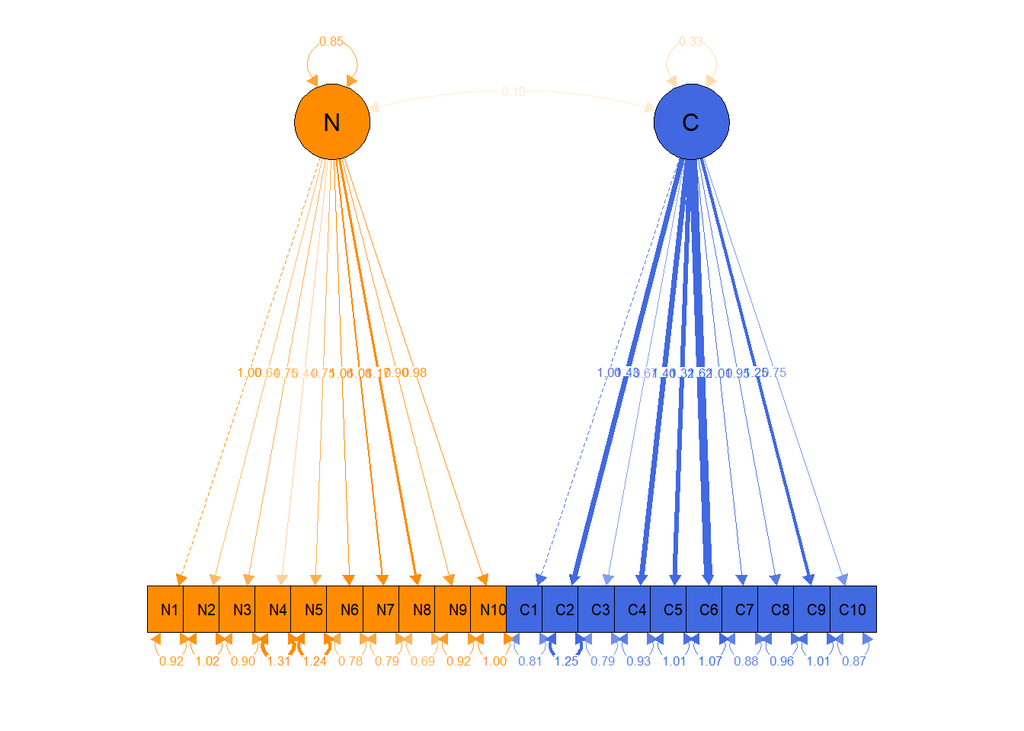

(a) Metodo Indicatore-LV

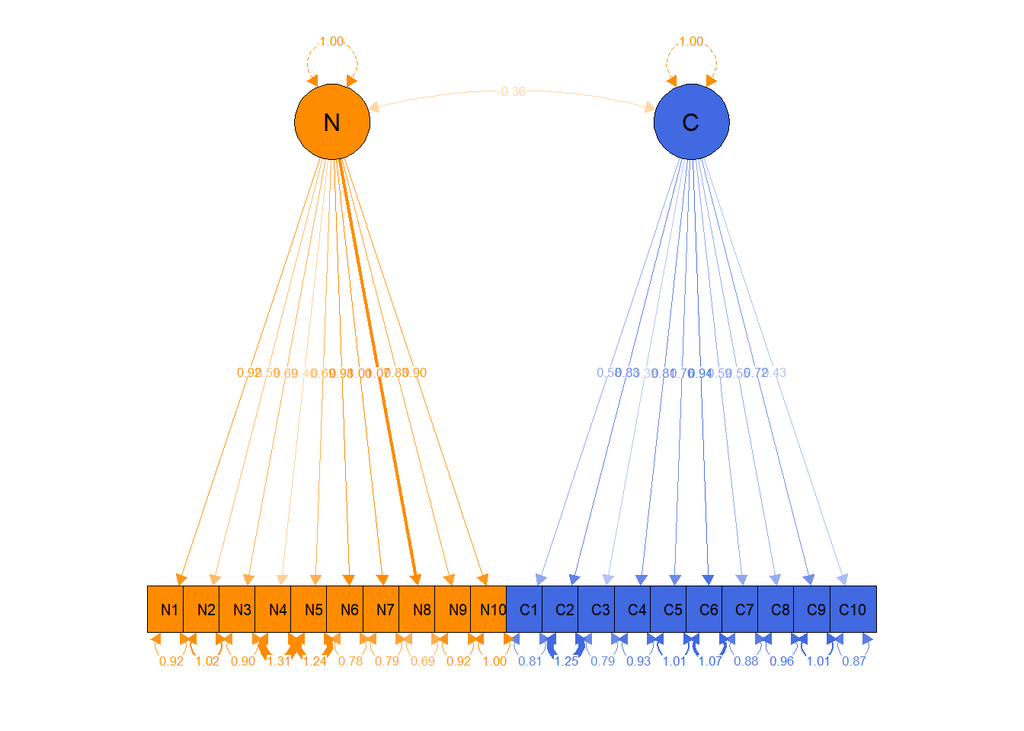

(b) Standardizzazione-LV

Figura 1: Modello Fattoriale Confermativo

# 7 Violazione normalità/linearità

Quando non si hanno a disposizone degli item che permettano di sostenere la linearità e normalità dei punteggi:

- Matrice di correlazione policorica (se $k \geq 3$)
- Matrice di correlazione tetracorica (se $k = 2$)

dove $k$ indica il numero di categorie di risposta

## 7.1 Correlazione tetracorica e le soglie

Le risposte agli item $Y_i$ sono la realizzazione di una *variabile latente* $Y_i^*$

$Y_i^*$ è continua e distribuita normalmente.. $Y_i$ no!

$$Y_i =
\begin{cases}
1 & \text{se } Y_i^* \geq \tau_i \\
0 & \text{se } Y_i^* < \tau_i
\end{cases}$$

dove $\tau_i$ è una soglia fissa (incognita) da cui dipende la risposta positiva

$$r_{\text{tet}_{Y_i Y_j}} = r_{Y_i^* Y_j^*}$$

```
Call: tetrachoric(x = table(LSAT[, 1], LSAT[, 2]))
tetrachoric correlation
[1] 0.17

 with tau of
    0     0
-1.43 -0.55
```

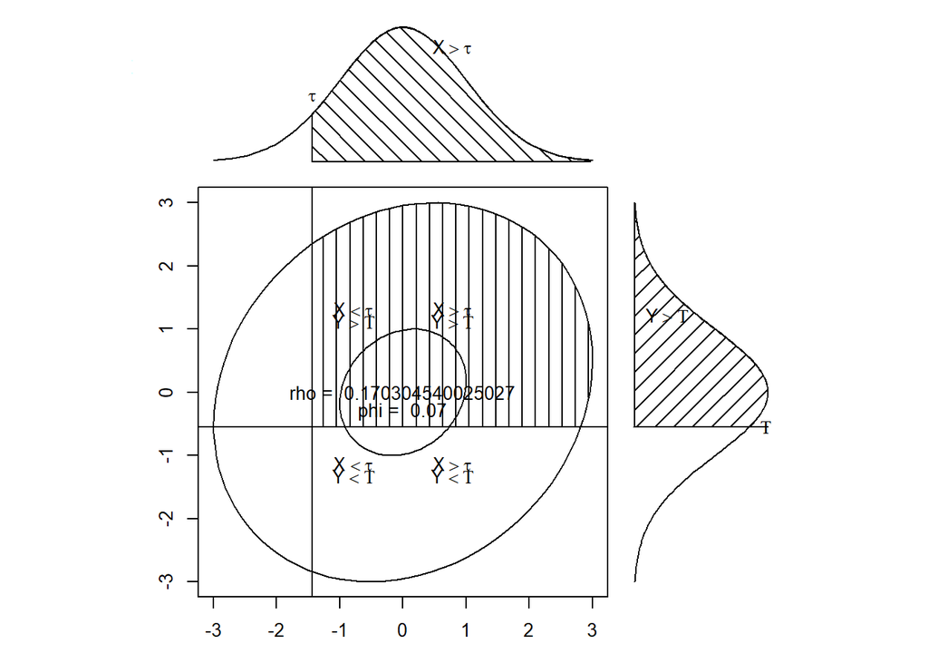

**Attenzione!**

In questo caso, vanno considerati come parametri del modello anche le soglie stimate per ogni item

Ma le soglie fanno parte anche dell’informazione iniziale a disposizione per stimare i parametri!

## 7.2 Conteggio dell’informazione

Avendo $I = 4$ con $k=5$, la matrice di covarianza è:

$$S =
\begin{pmatrix}
s_{11} & s_{12} & s_{13} & s_{14} \\
s_{21} & s_{22} & s_{23} & s_{24} \\
s_{31} & s_{32} & s_{33} & s_{34} \\
s_{41} & s_{42} & s_{43} & s_{44}
\end{pmatrix}$$
Ma considerando il caso di variabili categoriali e quindi la correlazione policorica:

$$S =
\begin{pmatrix}
1 & s_{12} & s_{13} & s_{14} \\
s_{21} & 1 & s_{23} & s_{24} \\
s_{31} & s_{32} & 1 & s_{34} \\
s_{41} & s_{42} & s_{43} & 1
\end{pmatrix}$$

Perché le variabili osservate sono prese come realizzazione di variabili latenti standardizzate. Di conseguenza, $S$ diventa una matrice di correlazione.

Il numero di parametri unici in $S$ è

$$\dfrac{I(I-1)}{2}$$
In questo caso, sono i 6 elementi nel triangolo inferiore (o nel triangolo superiore)

Nella quantità di informazione, vanno contate anche le soglie per ogni item

$$\sum_{i = 1}^{I} (k_i -1)$$

L’informazione totale in caso di item considerati a livello ordinale è quindi

$$\dfrac{I(I-1)}{2} + \sum_{i = 1}^{I} (k_i -1)$$

Nell’esempio di prima, con $I = 4$ e $k = 5$:

$$\dfrac{4(4-1)}{2} + \sum_{i = 1}^{4} (5 -1) = 6 + 4 \times 4 = 22$$

Il discorso del calcolo dei gradi di libertà e della loro logica è come quello in Sezione 4.1.1

**NB**

Per la matrice tetracorica vale lo stesso identico discorso, dove però $k = 2$

## 7.3 Conteggio dei parametri

Si applica la stessa metodologia per scalare e interpretare i parametri di quella presentata in Sezione 5.2, ovvero

- **Metodo indicatore-LV**: La saturazione del primo item di ogni dimensione viene usato per scalare sia la variabile latente sia le saturazioni di tutti gli altri item
- **Metodo della standardizzazione della LV**: Vengono standardizzate le variabili latenti, creando una scala comune per l’interpretazione delle saturazioni

Il tipo di scalatura non influisce sul numero totale di parametri stimati (ma su quali parametri vengono stimati).

Nel caso della correlazioni basate sulle soglie (policoriche o tetracoriche), il conteggio dei parametri deve includere anche il conteggio delle soglie

$$\zeta = \{\Lambda, \boldsymbol{Var(\varepsilon_i)}, \Phi, \tau\}$$

dove $\tau$ è la matrice item per soglia

### 7.3.1 Matrice policorica

```
Call: polychoric(x = d[, colnames(d) %in% c(labels$C[1:5], labels$N[1:5])])
Polychoric correlations
   N1    N2    N3    N4    N5    C1    C2    C3    C4    C5
N1  1.00
N2  0.56  1.00
N3  0.68  0.44  1.00
N4  0.27  0.30  0.29  1.00
N5  0.44  0.25  0.38  0.16  1.00
C1 -0.12 -0.16 -0.03 -0.07 -0.12  1.00
C2 -0.08 -0.06 -0.12 -0.11 -0.01  0.30  1.00
C3 -0.05 -0.12  0.19  0.04 -0.11  0.39  0.18  1.00
C4 -0.32 -0.18 -0.27 -0.17 -0.26  0.39  0.53  0.27  1.00
C5 -0.14 -0.13 -0.15 -0.07 -0.15  0.32  0.41  0.26  0.41  1.00

 with tau of
       1     2      3    4
N1 -1.18 -0.48  0.111 0.73
N2 -0.94 -0.10  0.628 1.47
N3 -1.68 -1.00 -0.515 0.31
N4 -1.43 -0.65  0.040 0.80
N5 -0.95 -0.33  0.249 1.06
C1 -1.54 -0.70  0.223 1.17
C2 -0.88 -0.18  0.301 0.89
C3 -2.20 -1.42 -0.736 0.23
C4 -1.23 -0.59  0.081 0.87
C5 -0.67  0.01  0.665 1.38
```

**Calcolo dell’informazione**

$$I = 10 \qquad k = 5$$
$$\dfrac{I(I-1)}{2} + \sum_{i = 1}^I (k_i -1) = \dfrac{10(10-1)}{2} + \sum_{i = 1}^{10} (5 -1) = 85$$

## 7.4 Parametri stimati

IL numero totale di parametri stimati rimane uguale ma va teneuto conto del metodo di scala delle variabili latenti usato.

Il conteggio generale dei parametri è uguale a quello presentato in Sezione 5.2.

In entrambi i casi, vanno aggiunti i parametri relativi alle soglie

**Attenzione!!**

Siccome il modello è ordinale (ovvero i dati osservati sono la realizzazione di variabili latenti con varianza nota) **non vengono stimate le varianze d’errore degli item**

$$\tau = I\times(k-1)$$

Nell’esempio con $I = 20$ item con $k = 5$ dove vengono specificato $F = 2$ fattori latenti (di seguito viene riportato il caso in cui viene scalato con metodo indicatore-variabile latente):

$$(20-2) + \dfrac{2(2+1)}{2} + 20(5-1) = 101$$

```
     id lhs  op rhs user block group free ustart exo label plabel  start    est
1     1   N  =~  N1    1     1     1    0      1   0         .p1.  1.000  1.000
2     2   N  =~  N2    1     1     1    1     NA   0         .p2.  0.658  0.726
3     3   N  =~  N3    1     1     1    2     NA   0         .p3.  0.849  0.895
4     4   N  =~  N4    1     1     1    3     NA   0         .p4.  0.450  0.503
5     5   N  =~  N5    1     1     1    4     NA   0         .p5.  0.629  0.729
6     6   N  =~  N6    1     1     1    5     NA   0         .p6.  0.870  1.032
7     7   N  =~  N7    1     1     1    6     NA   0         .p7.  0.773  1.107
8     8   N  =~  N8    1     1     1    7     NA   0         .p8.  0.805  1.173
9     9   N  =~  N9    1     1     1    8     NA   0         .p9.  0.795  0.915
10   10   N  =~ N10    1     1     1    9     NA   0        .p10.  0.752  0.953
11   11   C  =~  C1    1     1     1    0      1   0        .p11.  1.000  1.000
12   12   C  =~  C2    1     1     1   10     NA   0        .p12.  0.865  1.059
13   13   C  =~  C3    1     1     1   11     NA   0        .p13.  0.840  0.743
14   14   C  =~  C4    1     1     1   12     NA   0        .p14.  0.976  1.370
```

[output cut: 317 more lines]

## 7.5 Fit del modello

```
lavaan 0.6-19 ended normally after 30 iterations

  Estimator                                       DWLS
  Optimization method                           NLMINB
  Number of model parameters                       101

  Number of observations                           498

Model Test User Model:
                                              Standard      Scaled
  Test Statistic                              1007.367     994.065
  Degrees of freedom                               169         169
  P-value (Chi-square)                           0.000       0.000
  Scaling correction factor                                  1.087
  Shift parameter                                           67.554
    simple second-order correction

Model Test Baseline Model:

  Test statistic                             17488.238    7449.890
  Degrees of freedom                               190         190
  P-value                                        0.000       0.000
  Scaling correction factor                                  2.383

User Model versus Baseline Model:

  Comparative Fit Index (CFI)                    0.952       0.886
  Tucker-Lewis Index (TLI)                       0.946       0.872

  Robust Comparative Fit Index (CFI)                         0.761
  Robust Tucker-Lewis Index (TLI)                            0.731

Root Mean Square Error of Approximation:

  RMSEA                                          0.100       0.099
  90 Percent confidence interval - lower         0.094       0.093
  90 Percent confidence interval - upper         0.106       0.105
  P-value H_0: RMSEA <= 0.050                    0.000       0.000
  P-value H_0: RMSEA >= 0.080                    1.000       1.000

```

[output cut: 139 more lines]

```
   .N8                0.223
   .N9                0.527
   .N10               0.487
   .C1                0.664
   .C2                0.623
   .C3                0.814
   .C4                0.370
   .C5                0.615
   .C6                0.478
   .C7                0.721
   .C8                0.683
   .C9                0.663
   .C10               0.797
    N                 0.565    0.033   17.260    0.000
    C                 0.336    0.042    8.024    0.000
```

# 8 Attendbilità

**Disclaimer**

Tutto il discorso che segue sull’attendbilità e sulla sua valutazione riguarda la Classical Test Theory

Grado in cui una procedura di misurazione produce lo stesso risultato in prove ripetute

$$X = V + E$$

$X$: misura rilevata\ $V$: parte vera\ $E$: errore: fluttuazioni casuali oppure costante e sistematico

L’attendibilità di una misura è la proporzione di $X$ che non riflette l’errore di misurazione:

$$\rho = \dfrac{V}{V + E}
\tag{1}$$

Problema: Non è possibile conoscere $V$ (non lo osserviamo mai) $\rightarrow$ Non è effettivmente possibile stimare l’attendibilità di una misura a partire dalla definizione in Equazione 1

Vengono utilizzate delle metodologie che perettono di approssimare il calcolo di $V$:

**Attendibilità test-retest**

Viene somministrato lo stesso test allo stesso gruppo di soggetti in due momenti distinti (solitamente vengono fatti passare almeno 3 mesi)

Si calcola il coefficiente di correlazione tra i punteggi ottenuti nelle due somministrazioni

**coefficiente di stabilità**

**Forme parallele**

Vengono somministrate due versioni dello stesso test che possono essere considerate equivalenti allo stesso gruppo di persone

Il contenuto, la formulazione degli item e degli eventuali distrattori devono essere pressapoco identici

Si calcola la correlazione tra i punteggi ottenuti ai due test

**coefficiente di equivalenza**

**Split-Half**

Si basa sulla somministrazione di una singola misura che viene suddivisa in due metà equivalenti (in termini di copertura del dominio di contenuto)

Viene calcolata la correlazione tra i punteggi che si ottengono dalle due metà $\rightarrow$ attendibilità che si osserverebbe su una misura lunga la metà dell’originale!

Viene impiegato il coefficiente di Spearman-Brown per calcolare l’attendbilità complessiva dell’intera misura

**coefficiente di coerenza interna**

## 8.1 $\alpha$ di Cronbach

è la misura di attendibilità sicuramente più conosciuta e usata

Interamente basata sulla correlazione tra gli item

$$\alpha = \dfrac{I}{I-1} \left( 1- \dfrac{\sum_{i = 1}^I \sigma_{X_i}^2}{\sigma_X^2}\right)$$

dove

$X = \sum_{i = 1}^I X_i$: punteggio totale al test

$\sigma_X^2$: varianza del punteggio totale

$\sigma_{X_i}^2$: varianze degli item

### 8.1.1 Cut off

| $\alpha$ | Interpretazione |
| --- | --- |
| $<.70$ | inaccettabile |
| $.70−.79$ | accettabile |
| $.80−.89$ | buona |
| $\geq 90$ | eccellente |

**Attenzione!**

Il valore di $\alpha$ aumenta all’aumentare del numero di item, indipendentemente dal fatto che siano utili o meno

Non si accorge della multidimensionalità: Può essere alto anche se la scala misura più costrutti diversi

## 8.2 Big Five

```
Some items ( C1 C2 C3 C4 C5 C6 C7 C8 C9 C10 ) were negatively correlated with the first principal component and
probably should be reversed.
To do this, run the function again with the 'check.keys=TRUE' option
```

```
 raw_alpha std.alpha   G6(smc) average_r      S/N        ase     mean        sd
  0.705802 0.7049413 0.8016712 0.1067104 2.389156 0.01959568 3.205723 0.4828887
   median_r
 0.02863595
```

Sbagliato!!

In maniera corretta:

```
 raw_alpha std.alpha  G6(smc) average_r      S/N         ase     mean        sd
 0.8676442 0.8659247 0.876357  0.392411 6.458495 0.008709927 3.094177 0.8677234
  median_r
 0.3870844
```

```
 raw_alpha std.alpha   G6(smc) average_r      S/N        ase     mean        sd
 0.8142006 0.8127849 0.8118898 0.3027204 4.341448 0.01218387 3.317269 0.7298349
  median_r
 0.3030961
```

### 8.2.1 $\alpha$ se l’item è eliminato

Misura del contributo di ogni singolo item alla **coerenza interna** (non è un giudizio assoluto sulla bontà dell’item o su quanto contirbuisce alla misurazione del contrutto)

$$\Delta \alpha = \alpha_{(-i)} - \alpha$$

Se:

$\Delta \alpha \geq .05$: L’item probabilmente non contribuisce alla coerenza interna

$0 < \Delta \alpha .02$: Va bene così

$< 0 $: Togliere l’item peggiora la coerenza interna della scala

Sapendo che

```
 raw_alpha std.alpha   G6(smc) average_r      S/N        ase     mean        sd
 0.8142006 0.8127849 0.8118898 0.3027204 4.341448 0.01218387 3.317269 0.7298349
  median_r
 0.3030961
```

le statistiche relativamente ad $\alpha_{(-1)}$ sono:

```
    raw_alpha std.alpha alpha se
C1       0.80      0.79     0.01
C2       0.80      0.80     0.01
C3       0.81      0.81     0.01
C4       0.79      0.79     0.01
C5       0.79      0.79     0.01
C6       0.79      0.79     0.01
C7       0.80      0.80     0.01
C8       0.80      0.80     0.01
C9       0.79      0.79     0.01
C10      0.81      0.80     0.01
```